# Adding Variables and Filtering Data - By User

Pedro Salguero

08 noviembre, 2022

## Creating new variables from current data

### Symtoms day before Admission

Numerical variable that indicates how many days of symptoms each patients had before hospital admission.

### Sum of Comorbidities

Numerical variable which count the number of comorbidities each patient have. To be a Former Smoker counts as 0,5.

### P/F variable

New numerical variable related to the ratio of arterial oxygen partial pressure (PaO2 in mmHg) to fractional inspired oxygen (FiO2 expressed as a fraction, not a percentage).

# Filtering

From here we are going to filter some patients that do not meet the condutions doctors establish. It is not a procedure of exploratory analysis, just deletion of non-interested samples.

## Data before Filtering

### Calabria

|  | Dataset statistics |
| --- | --- |
| Number of observations | 193 |
| Number of variables | 381 |

### Humanitas

|  | Dataset statistics |
| --- | --- |
| Number of observations | 627 |
| Number of variables | 250 |

### Monza

|  | Dataset statistics |
| --- | --- |
| Number of observations | 642 |
| Number of variables | 149 |

### Spain

|  | Dataset statistics |
| --- | --- |
| Number of observations | 12464 |
| Number of variables | 88 |

### Italian

|  | Dataset statistics |
| --- | --- |
| Number of observations | 1462 |
| Number of variables | 138 |

### European

|  | Dataset statistics |
| --- | --- |
| Number of observations | 13926 |
| Number of variables | 59 |

## Outcome Summary

### Calabria

|  | Patients | Discharged alive | Hospitalization | Transfer to other facility | Death |
| --- | --- | --- | --- | --- | --- |
| Value | 193 | 134 | 3 | 19 | 37 |
| Proportion | 1 | 0.6943 | 0.0155 | 0.0984 | 0.1917 |

### Humanitas

|  | Patients | Death | Discharged alive |
| --- | --- | --- | --- |
| Value | 627 | 131 | 496 |
| Proportion | 1 | 0.2089 | 0.7911 |

### Monza

|  | Patients | Discharged alive | Transfer to other facility | Death |
| --- | --- | --- | --- | --- |
| Value | 642 | 381 | 132 | 127 |
| Proportion | 1 | 0.5935 | 0.2056 | 0.1978 |

### Spain

|  | Patients | Death | Discharged alive |
| --- | --- | --- | --- |
| Value | 12464 | 1983 | 10477 |
| Proportion | 1 | 0.1591 | 0.8406 |

### Italian

|  | Patients | Discharged alive | Hospitalization | Transfer to other facility | Death |
| --- | --- | --- | --- | --- | --- |
| Value | 1462 | 1011 | 3 | 151 | 295 |
| Proportion | 1 | 0.6915 | 0.0021 | 0.1033 | 0.2018 |

### European

|  | Patients | Discharged alive | Hospitalization | Transfer to other facility | Death |
| --- | --- | --- | --- | --- | --- |
| Value | 13926 | 11488 | 3 | 151 | 2278 |
| Proportion | 1 | 0.8249 | 2e-04 | 0.0108 | 0.1636 |

## Mandatory Variables Study

In next section we are going to study the mandatory variables “cestdat, dsstdtc, dsterm, sex, age_estimateyears” all the patients need to perform a survival analysis.

### Calabria

| Info |
| --- |
| No observations with problems have been found |

### Humanitas

| Patients | Missing Variables |
| --- | --- |
| ICH-336 | cestdat |
| ICH-541 | cestdat |
| ICH-545 | cestdat |
| ICH-546 | cestdat |
| ICH-548 | cestdat |
| ICH-552 | cestdat |
| ICH-566 | cestdat |
| ICH-572 | cestdat |
| ICH-584 | cestdat |
| ICH-585 | cestdat |
| ICH-602 | cestdat |
| ICH-609 | cestdat |
| ICH-611 | cestdat |
| ICH-612 | cestdat |
| ICH-617 | cestdat |
| ICH-621 | cestdat |
| ICH-628 | cestdat |
| ICH-631 | cestdat |
| ICH-644 | cestdat |
| ICH-651 | cestdat |
| ICH-652 | cestdat |
| ICH-86 | cestdat |

### Monza

| Patients | Missing Variables |
| --- | --- |
| OMNI001-199 | cestdat |
| OMNI001-254 | dsstdtc, dsterm |
| OMNI001-338 | cestdat |
| OMNI001-373 | cestdat, dsstdtc, dsterm, sex, age_estimateyears |

### Spain

| Patients | Missing Variables |
| --- | --- |
| 1237-80 | cestdat |
| 1239-152 | age_estimateyears |
| 1239-155 | cestdat |
| 771-22 | cestdat |
| 771-24 | cestdat |
| 773-162 | cestdat |
| 773-191 | cestdat |
| 773-44 | cestdat |
| 774-9 | dsstdtc, dsterm |
| 778-68 | cestdat |
| 779-13 | cestdat |
| 782-107 | cestdat |
| 797-107 | age_estimateyears |
| 799-124 | sex |
| 799-48 | cestdat |
| 800-102 | cestdat |
| 800-115 | cestdat |
| 800-118 | cestdat |
| 800-133 | cestdat |
| 800-20 | cestdat |
| 800-38 | cestdat |
| 800-42 | cestdat |
| 800-51 | cestdat |
| 800-60 | cestdat |
| 800-69 | cestdat |
| 800-76 | cestdat |
| 801-69 | cestdat |
| 801-71 | cestdat |
| 802-115 | cestdat |
| 804-119 | cestdat |

[output cut: 60 more lines]

### Italian

| Patients | Missing Variables |
| --- | --- |
| ICH-336 | cestdat |
| ICH-541 | cestdat |
| ICH-545 | cestdat |
| ICH-546 | cestdat |
| ICH-548 | cestdat |
| ICH-552 | cestdat |
| ICH-566 | cestdat |
| ICH-572 | cestdat |
| ICH-584 | cestdat |
| ICH-585 | cestdat |
| ICH-602 | cestdat |
| ICH-609 | cestdat |
| ICH-611 | cestdat |
| ICH-612 | cestdat |
| ICH-617 | cestdat |
| ICH-621 | cestdat |
| ICH-628 | cestdat |
| ICH-631 | cestdat |
| ICH-644 | cestdat |
| ICH-651 | cestdat |
| ICH-652 | cestdat |
| ICH-86 | cestdat |
| OMNI001-199 | cestdat |
| OMNI001-254 | dsstdtc, dsterm |
| OMNI001-338 | cestdat |
| OMNI001-373 | cestdat, dsstdtc, dsterm, sex, age_estimateyears |

### European

| Patients | Missing Variables |
| --- | --- |
| ICH-336 | cestdat |
| ICH-541 | cestdat |
| ICH-545 | cestdat |
| ICH-546 | cestdat |
| ICH-548 | cestdat |
| ICH-552 | cestdat |
| ICH-566 | cestdat |
| ICH-572 | cestdat |
| ICH-584 | cestdat |
| ICH-585 | cestdat |
| ICH-602 | cestdat |
| ICH-609 | cestdat |
| ICH-611 | cestdat |
| ICH-612 | cestdat |
| ICH-617 | cestdat |
| ICH-621 | cestdat |
| ICH-628 | cestdat |
| ICH-631 | cestdat |
| ICH-644 | cestdat |
| ICH-651 | cestdat |
| ICH-652 | cestdat |
| ICH-86 | cestdat |
| OMNI001-199 | cestdat |
| OMNI001-254 | dsstdtc, dsterm |
| OMNI001-338 | cestdat |
| OMNI001-373 | cestdat, dsstdtc, dsterm, sex, age_estimateyears |
| 1237-80 | cestdat |
| 1239-152 | age_estimateyears |
| 1239-155 | cestdat |
| 771-22 | cestdat |

[output cut: 86 more lines]

## Enrolment and Admission Day Differences

We showed the patients that have a significant difference of days between the Most recent presentation/admission date at this facility: with variable “hostdat” and the Enrolment date / first COVID-19 assessment date: with variable “dsstdat”. The limit is set to 3 days.

### Calabria

| Patients | hostdat | dsstdat | Time Difference |
| --- | --- | --- | --- |
| 481-0001 | 2020-03-02 | 2020-03-20 | 18 days |
| 481-0005 | 2020-03-13 | 2020-03-20 | 7 days |
| 481-0025 | 2020-03-20 | 2020-03-12 | -8 days |
| 481-0026 | 2020-03-03 | 2020-03-20 | 17 days |
| 481-0034 | 2020-03-13 | 2020-03-24 | 11 days |
| 481-0038 | 2020-03-16 | 2020-03-12 | -4 days |
| 481-0089 | 2020-03-29 | 2020-03-20 | -9 days |
| 481-0090 | 2020-03-25 | 2020-03-29 | 4 days |
| 481-0105 | 2020-04-07 | 2020-03-31 | -7 days |
| 481-0108 | 2020-04-07 | 2020-03-31 | -7 days |
| 481-0124 | 2020-03-19 | 2020-03-13 | -6 days |
| 481-0129 | 2020-03-28 | 2020-03-24 | -4 days |
| 481-0135 | 2020-04-03 | 2020-04-12 | 9 days |
| 481-0155 | 2020-04-11 | 2020-03-11 | -31 days |
| 481-0185 | 2020-03-31 | 2020-03-08 | -23 days |

### Humanitas

| Info |
| --- |
| No observations with problems have been found |

### Monza

| Patients | hostdat | dsstdat | Time Difference |
| --- | --- | --- | --- |
| OMNI001-100 | 2020-03-28 | 2020-03-24 | -4 days |
| OMNI001-1002 | 2020-03-17 | 2020-03-13 | -4 days |
| OMNI001-101 | 2020-04-27 | 2020-04-19 | -8 days |
| OMNI001-1013 | 2020-03-20 | 2020-03-16 | -4 days |
| OMNI001-104 | 2020-03-05 | 2020-02-25 | -9 days |
| OMNI001-1046 | 2020-03-11 | 2020-03-06 | -5 days |
| OMNI001-110 | 2020-03-06 | 2020-03-11 | 5 days |
| OMNI001-1118 | 2020-03-23 | 2020-03-19 | -4 days |
| OMNI001-123 | 2020-02-27 | 2020-03-27 | 29 days |
| OMNI001-145 | 2020-03-31 | 2020-03-21 | -10 days |
| OMNI001-168 | 2020-03-23 | 2020-03-30 | 7 days |
| OMNI001-217 | 2020-03-24 | 2020-04-24 | 31 days |
| OMNI001-249 | 2020-03-16 | 2020-03-09 | -7 days |
| OMNI001-262 | 2020-03-14 | 2020-06-14 | 92 days |
| OMNI001-269 | 2020-03-19 | 2019-03-19 | -366 days |
| OMNI001-277 | 2020-03-20 | 2020-03-13 | -7 days |
| OMNI001-280 | 2020-03-25 | 2020-03-20 | -5 days |
| OMNI001-286 | 2020-04-16 | 2020-04-10 | -6 days |
| OMNI001-328 | 2020-03-22 | 2020-06-22 | 92 days |
| OMNI001-330 | 2020-03-20 | 2020-04-19 | 30 days |
| OMNI001-343 | 2020-03-23 | 2020-06-22 | 91 days |
| OMNI001-387 | 2020-03-18 | 2020-05-18 | 61 days |
| OMNI001-409 | 2020-02-29 | 2020-03-28 | 28 days |
| OMNI001-411 | 2020-03-26 | 2020-04-01 | 6 days |
| OMNI001-42 | 2020-03-26 | 2019-03-26 | -366 days |
| OMNI001-426 | 2020-03-19 | 2020-03-14 | -5 days |
| OMNI001-44 | 2020-03-22 | 2020-03-06 | -16 days |
| OMNI001-465 | 2020-03-03 | 2020-03-12 | 9 days |
| OMNI001-472 | 2020-03-23 | 2020-03-19 | -4 days |
| OMNI001-491 | 2020-03-23 | 2020-03-10 | -13 days |
| OMNI001-5 | 2020-04-18 | 2020-04-22 | 4 days |
| OMNI001-50 | 2020-03-28 | 2020-03-24 | -4 days |
| OMNI001-523 | 2020-03-30 | 2020-03-23 | -7 days |
| OMNI001-533 | 2020-03-13 | 2020-04-13 | 31 days |
| OMNI001-549 | 2020-03-23 | 2020-03-17 | -6 days |
| OMNI001-566 | 2020-03-29 | 2020-03-25 | -4 days |
| OMNI001-574 | 2020-02-27 | 2020-02-21 | -6 days |
| OMNI001-59 | 2020-03-17 | 2020-05-16 | 60 days |
| OMNI001-591 | 2020-03-16 | 2020-03-12 | -4 days |
| OMNI001-60 | 2020-03-25 | 2020-03-19 | -6 days |
| OMNI001-605 | 2020-03-29 | 2020-03-16 | -13 days |
| OMNI001-63 | 2020-03-17 | 2020-05-17 | 61 days |
| OMNI001-634 | 2020-03-06 | 2020-02-28 | -7 days |
| OMNI001-646 | 2020-03-03 | 2020-02-28 | -4 days |
| OMNI001-664 | 2020-03-18 | 2020-04-18 | 31 days |
| OMNI001-694 | 2020-03-19 | 2020-03-14 | -5 days |
| OMNI001-697 | 2020-05-19 | 2020-04-18 | -31 days |
| OMNI001-702 | 2020-05-05 | 2020-03-22 | -44 days |
| OMNI001-718 | 2020-05-24 | 2020-05-18 | -6 days |
| OMNI001-726 | 2020-03-23 | 2020-03-19 | -4 days |
| OMNI001-745 | 2020-03-11 | 2020-04-10 | 30 days |
| OMNI001-76 | 2020-03-27 | 2020-03-18 | -9 days |
| OMNI001-763 | 2020-04-15 | 2020-04-06 | -9 days |
| OMNI001-769 | 2020-03-31 | 2020-03-16 | -15 days |
| OMNI001-775 | 2020-03-29 | 2020-03-21 | -8 days |
| OMNI001-785 | 2020-03-31 | 2020-03-25 | -6 days |
| OMNI001-79 | 2020-03-27 | 2020-03-15 | -12 days |
| OMNI001-798 | 2020-03-01 | 2020-02-26 | -4 days |
| OMNI001-862 | 2020-03-14 | 2020-03-04 | -10 days |
| OMNI001-94 | 2020-03-25 | 2020-04-24 | 30 days |
| OMNI001-959 | 2020-03-22 | 2020-03-13 | -9 days |
| OMNI001-98 | 2020-03-05 | 2020-02-24 | -10 days |

### Spain

| Patients | hostdat | dsstdat | Time Difference |
| --- | --- | --- | --- |
| 1223-107 | 2020-03-28 | 2020-05-24 | 57 days |
| 1223-108 | 2020-03-29 | 2020-03-22 | -7 days |
| 1223-111 | 2020-03-10 | 2020-03-24 | 14 days |
| 1223-121 | 2020-03-30 | 2020-04-05 | 6 days |
| 1223-129 | 2020-03-28 | 2020-04-28 | 31 days |
| 1223-13 | 2020-03-31 | 2020-03-21 | -10 days |
| 1223-131 | 2020-03-10 | 2020-03-24 | 14 days |
| 1223-137 | 2020-03-27 | 2020-03-20 | -7 days |
| 1223-140 | 2020-03-31 | 2020-03-24 | -7 days |
| 1223-33 | 2020-04-18 | 2020-04-10 | -8 days |
| 1223-47 | 2020-04-11 | 2020-04-03 | -8 days |
| 1223-48 | 2020-03-31 | 2020-04-05 | 5 days |
| 1223-7 | 2020-03-25 | 2020-03-20 | -5 days |
| 1223-70 | 2020-03-23 | 2020-03-19 | -4 days |
| 1223-73 | 2020-04-06 | 2020-04-14 | 8 days |
| 1223-77 | 2020-03-30 | 2020-04-08 | 9 days |
| 1223-91 | 2020-04-17 | 2020-04-05 | -12 days |
| 1223-93 | 2020-03-24 | 2020-03-16 | -8 days |
| 1224-29 | 2020-04-19 | 2020-04-14 | -5 days |
| 1224-44 | 2020-04-01 | 2020-03-25 | -7 days |
| 1224-45 | 2020-03-26 | 2020-03-20 | -6 days |
| 1224-5 | 2020-04-24 | 2020-04-14 | -10 days |
| 1225-4 | 2020-03-25 | 2020-04-01 | 7 days |
| 1226-14 | 2020-04-13 | 2020-04-08 | -5 days |
| 1227-3 | 2020-03-21 | 2020-04-12 | 22 days |
| 1230-29 | 2020-03-18 | 2020-03-22 | 4 days |
| 1232-27 | 2020-03-20 | 2020-03-27 | 7 days |
| 1232-40 | 2020-03-24 | 2020-03-28 | 4 days |
| 1232-50 | 2020-03-28 | 2020-04-01 | 4 days |
| 1232-52 | 2020-03-26 | 2020-03-31 | 5 days |

[output cut: 1548 more lines]

### Italian

| Patients | hostdat | dsstdat | Time Difference |
| --- | --- | --- | --- |
| 481-0001 | 2020-03-02 | 2020-03-20 | 18 days |
| 481-0005 | 2020-03-13 | 2020-03-20 | 7 days |
| 481-0025 | 2020-03-20 | 2020-03-12 | -8 days |
| 481-0026 | 2020-03-03 | 2020-03-20 | 17 days |
| 481-0034 | 2020-03-13 | 2020-03-24 | 11 days |
| 481-0038 | 2020-03-16 | 2020-03-12 | -4 days |
| 481-0089 | 2020-03-29 | 2020-03-20 | -9 days |
| 481-0090 | 2020-03-25 | 2020-03-29 | 4 days |
| 481-0105 | 2020-04-07 | 2020-03-31 | -7 days |
| 481-0108 | 2020-04-07 | 2020-03-31 | -7 days |
| 481-0124 | 2020-03-19 | 2020-03-13 | -6 days |
| 481-0129 | 2020-03-28 | 2020-03-24 | -4 days |
| 481-0135 | 2020-04-03 | 2020-04-12 | 9 days |
| 481-0155 | 2020-04-11 | 2020-03-11 | -31 days |
| 481-0185 | 2020-03-31 | 2020-03-08 | -23 days |
| OMNI001-100 | 2020-03-28 | 2020-03-24 | -4 days |
| OMNI001-1002 | 2020-03-17 | 2020-03-13 | -4 days |
| OMNI001-101 | 2020-04-27 | 2020-04-19 | -8 days |
| OMNI001-1013 | 2020-03-20 | 2020-03-16 | -4 days |
| OMNI001-104 | 2020-03-05 | 2020-02-25 | -9 days |
| OMNI001-1046 | 2020-03-11 | 2020-03-06 | -5 days |
| OMNI001-110 | 2020-03-06 | 2020-03-11 | 5 days |
| OMNI001-1118 | 2020-03-23 | 2020-03-19 | -4 days |
| OMNI001-123 | 2020-02-27 | 2020-03-27 | 29 days |
| OMNI001-145 | 2020-03-31 | 2020-03-21 | -10 days |
| OMNI001-168 | 2020-03-23 | 2020-03-30 | 7 days |
| OMNI001-217 | 2020-03-24 | 2020-04-24 | 31 days |
| OMNI001-249 | 2020-03-16 | 2020-03-09 | -7 days |
| OMNI001-262 | 2020-03-14 | 2020-06-14 | 92 days |
| OMNI001-269 | 2020-03-19 | 2019-03-19 | -366 days |
| OMNI001-277 | 2020-03-20 | 2020-03-13 | -7 days |
| OMNI001-280 | 2020-03-25 | 2020-03-20 | -5 days |
| OMNI001-286 | 2020-04-16 | 2020-04-10 | -6 days |
| OMNI001-328 | 2020-03-22 | 2020-06-22 | 92 days |
| OMNI001-330 | 2020-03-20 | 2020-04-19 | 30 days |
| OMNI001-343 | 2020-03-23 | 2020-06-22 | 91 days |
| OMNI001-387 | 2020-03-18 | 2020-05-18 | 61 days |
| OMNI001-409 | 2020-02-29 | 2020-03-28 | 28 days |
| OMNI001-411 | 2020-03-26 | 2020-04-01 | 6 days |
| OMNI001-42 | 2020-03-26 | 2019-03-26 | -366 days |
| OMNI001-426 | 2020-03-19 | 2020-03-14 | -5 days |
| OMNI001-44 | 2020-03-22 | 2020-03-06 | -16 days |
| OMNI001-465 | 2020-03-03 | 2020-03-12 | 9 days |
| OMNI001-472 | 2020-03-23 | 2020-03-19 | -4 days |
| OMNI001-491 | 2020-03-23 | 2020-03-10 | -13 days |
| OMNI001-5 | 2020-04-18 | 2020-04-22 | 4 days |
| OMNI001-50 | 2020-03-28 | 2020-03-24 | -4 days |
| OMNI001-523 | 2020-03-30 | 2020-03-23 | -7 days |
| OMNI001-533 | 2020-03-13 | 2020-04-13 | 31 days |
| OMNI001-549 | 2020-03-23 | 2020-03-17 | -6 days |
| OMNI001-566 | 2020-03-29 | 2020-03-25 | -4 days |
| OMNI001-574 | 2020-02-27 | 2020-02-21 | -6 days |
| OMNI001-59 | 2020-03-17 | 2020-05-16 | 60 days |
| OMNI001-591 | 2020-03-16 | 2020-03-12 | -4 days |
| OMNI001-60 | 2020-03-25 | 2020-03-19 | -6 days |
| OMNI001-605 | 2020-03-29 | 2020-03-16 | -13 days |
| OMNI001-63 | 2020-03-17 | 2020-05-17 | 61 days |
| OMNI001-634 | 2020-03-06 | 2020-02-28 | -7 days |
| OMNI001-646 | 2020-03-03 | 2020-02-28 | -4 days |
| OMNI001-664 | 2020-03-18 | 2020-04-18 | 31 days |
| OMNI001-694 | 2020-03-19 | 2020-03-14 | -5 days |
| OMNI001-697 | 2020-05-19 | 2020-04-18 | -31 days |
| OMNI001-702 | 2020-05-05 | 2020-03-22 | -44 days |
| OMNI001-718 | 2020-05-24 | 2020-05-18 | -6 days |
| OMNI001-726 | 2020-03-23 | 2020-03-19 | -4 days |
| OMNI001-745 | 2020-03-11 | 2020-04-10 | 30 days |
| OMNI001-76 | 2020-03-27 | 2020-03-18 | -9 days |
| OMNI001-763 | 2020-04-15 | 2020-04-06 | -9 days |
| OMNI001-769 | 2020-03-31 | 2020-03-16 | -15 days |
| OMNI001-775 | 2020-03-29 | 2020-03-21 | -8 days |
| OMNI001-785 | 2020-03-31 | 2020-03-25 | -6 days |
| OMNI001-79 | 2020-03-27 | 2020-03-15 | -12 days |
| OMNI001-798 | 2020-03-01 | 2020-02-26 | -4 days |
| OMNI001-862 | 2020-03-14 | 2020-03-04 | -10 days |
| OMNI001-94 | 2020-03-25 | 2020-04-24 | 30 days |
| OMNI001-959 | 2020-03-22 | 2020-03-13 | -9 days |
| OMNI001-98 | 2020-03-05 | 2020-02-24 | -10 days |

### European

| Patients | hostdat | dsstdat | Time Difference |
| --- | --- | --- | --- |
| 481-0001 | 2020-03-02 | 2020-03-20 | 18 days |
| 481-0005 | 2020-03-13 | 2020-03-20 | 7 days |
| 481-0025 | 2020-03-20 | 2020-03-12 | -8 days |
| 481-0026 | 2020-03-03 | 2020-03-20 | 17 days |
| 481-0034 | 2020-03-13 | 2020-03-24 | 11 days |
| 481-0038 | 2020-03-16 | 2020-03-12 | -4 days |
| 481-0089 | 2020-03-29 | 2020-03-20 | -9 days |
| 481-0090 | 2020-03-25 | 2020-03-29 | 4 days |
| 481-0105 | 2020-04-07 | 2020-03-31 | -7 days |
| 481-0108 | 2020-04-07 | 2020-03-31 | -7 days |
| 481-0124 | 2020-03-19 | 2020-03-13 | -6 days |
| 481-0129 | 2020-03-28 | 2020-03-24 | -4 days |
| 481-0135 | 2020-04-03 | 2020-04-12 | 9 days |
| 481-0155 | 2020-04-11 | 2020-03-11 | -31 days |
| 481-0185 | 2020-03-31 | 2020-03-08 | -23 days |
| OMNI001-100 | 2020-03-28 | 2020-03-24 | -4 days |
| OMNI001-1002 | 2020-03-17 | 2020-03-13 | -4 days |
| OMNI001-101 | 2020-04-27 | 2020-04-19 | -8 days |
| OMNI001-1013 | 2020-03-20 | 2020-03-16 | -4 days |
| OMNI001-104 | 2020-03-05 | 2020-02-25 | -9 days |
| OMNI001-1046 | 2020-03-11 | 2020-03-06 | -5 days |
| OMNI001-110 | 2020-03-06 | 2020-03-11 | 5 days |
| OMNI001-1118 | 2020-03-23 | 2020-03-19 | -4 days |
| OMNI001-123 | 2020-02-27 | 2020-03-27 | 29 days |
| OMNI001-145 | 2020-03-31 | 2020-03-21 | -10 days |
| OMNI001-168 | 2020-03-23 | 2020-03-30 | 7 days |
| OMNI001-217 | 2020-03-24 | 2020-04-24 | 31 days |
| OMNI001-249 | 2020-03-16 | 2020-03-09 | -7 days |
| OMNI001-262 | 2020-03-14 | 2020-06-14 | 92 days |
| OMNI001-269 | 2020-03-19 | 2019-03-19 | -366 days |

[output cut: 1625 more lines]

## Symptoms and Admission Day Differences

We showed the patients that have a difference of days greater than 0 between the Onset date of first/earliest symptom: with variable “cestdat” and the Most recent presentation/admission date at this facility: with variable “hostdat”. Only negative values are shown (symptoms after the admission).

### Calabria

| Patients | cestdat | hostdat | Time Difference |
| --- | --- | --- | --- |
| 481-0164 | 2020-03-11 | 2020-03-09 | -2 days |

### Humanitas

| Patients | cestdat | hostdat | Time Difference |
| --- | --- | --- | --- |
| ICH-297 | 2020-04-01 | 2020-03-06 | -26 days |
| ICH-301 | 2020-03-13 | 2020-03-07 | -6 days |
| ICH-393 | 2020-04-16 | 2020-03-20 | -27 days |
| ICH-407 | 2020-03-03 | 2020-02-22 | -10 days |
| ICH-419 | 2020-03-05 | 2020-03-04 | -1 days |
| ICH-428 | 2020-03-04 | 2020-03-03 | -1 days |
| ICH-433 | 2020-03-05 | 2020-03-04 | -1 days |
| ICH-436 | 2020-03-24 | 2020-03-04 | -20 days |
| ICH-453 | 2020-03-19 | 2020-03-14 | -5 days |
| ICH-605 | 2020-05-04 | 2020-04-15 | -19 days |

### Monza

| Patients | cestdat | hostdat | Time Difference |
| --- | --- | --- | --- |
| OMNI001-330 | 2020-04-09 | 2020-03-20 | -20 days |
| OMNI001-342 | 2020-05-14 | 2020-03-18 | -57 days |
| OMNI001-411 | 2020-04-01 | 2020-03-26 | -6 days |
| OMNI001-587 | 2020-05-14 | 2020-03-30 | -45 days |
| OMNI001-60 | 2020-04-17 | 2020-03-25 | -23 days |
| OMNI001-63 | 2020-05-10 | 2020-03-17 | -54 days |
| OMNI001-664 | 2020-04-14 | 2020-03-18 | -27 days |
| OMNI001-745 | 2020-03-16 | 2020-03-11 | -5 days |

### Spain

| Patients | cestdat | hostdat | Time Difference |
| --- | --- | --- | --- |
| 1223-129 | 2020-04-28 | 2020-03-28 | -31 days |
| 1223-88 | 2020-04-11 | 2020-04-10 | -1 days |
| 1233-35 | 2020-05-20 | 2020-03-24 | -57 days |
| 1234-28 | 2020-04-02 | 2020-03-30 | -3 days |
| 1237-177 | 2020-06-15 | 2020-04-21 | -55 days |
| 1237-35 | 2020-05-14 | 2020-03-20 | -55 days |
| 1238-2 | 2020-03-15 | 2020-03-10 | -5 days |
| 1240-72 | 2020-03-15 | 2020-01-31 | -44 days |
| 1240-82 | 2020-04-19 | 2020-03-23 | -27 days |
| 1242-3 | 2020-05-24 | 2020-04-06 | -48 days |
| 771-10 | 2020-03-26 | 2020-02-03 | -52 days |
| 771-17 | 2020-04-23 | 2020-04-02 | -21 days |
| 771-19 | 2020-03-29 | 2020-03-12 | -17 days |
| 771-21 | 2020-04-04 | 2020-04-02 | -2 days |
| 772-1 | 2020-03-13 | 2020-03-09 | -4 days |
| 772-109 | 2020-03-26 | 2020-03-12 | -14 days |
| 773-103 | 2020-05-18 | 2020-03-26 | -53 days |
| 773-127 | 2020-05-24 | 2020-03-31 | -54 days |
| 773-178 | 2020-06-02 | 2020-04-07 | -56 days |
| 774-31 | 2020-04-28 | 2020-04-08 | -20 days |
| 777-28 | 2020-04-23 | 2020-03-27 | -27 days |
| 779-37 | 2020-03-20 | 2020-03-17 | -3 days |
| 780-114 | 2020-04-03 | 2020-03-02 | -32 days |
| 780-190 | 2020-04-23 | 2020-04-22 | -1 days |
| 780-83 | 2020-03-30 | 2020-03-22 | -8 days |
| 797-54 | 2020-03-12 | 2020-03-04 | -8 days |
| 797-88 | 2020-04-09 | 2020-03-31 | -9 days |
| 800-108 | 2020-03-29 | 2020-03-28 | -1 days |
| 800-123 | 2020-03-14 | 2020-02-28 | -15 days |
| 800-80 | 2020-03-27 | 2020-03-23 | -4 days |

[output cut: 98 more lines]

### Italian

| Patients | cestdat | hostdat | Time Difference |
| --- | --- | --- | --- |
| 481-0164 | 2020-03-11 | 2020-03-09 | -2 days |
| ICH-297 | 2020-04-01 | 2020-03-06 | -26 days |
| ICH-301 | 2020-03-13 | 2020-03-07 | -6 days |
| ICH-393 | 2020-04-16 | 2020-03-20 | -27 days |
| ICH-407 | 2020-03-03 | 2020-02-22 | -10 days |
| ICH-419 | 2020-03-05 | 2020-03-04 | -1 days |
| ICH-428 | 2020-03-04 | 2020-03-03 | -1 days |
| ICH-433 | 2020-03-05 | 2020-03-04 | -1 days |
| ICH-436 | 2020-03-24 | 2020-03-04 | -20 days |
| ICH-453 | 2020-03-19 | 2020-03-14 | -5 days |
| ICH-605 | 2020-05-04 | 2020-04-15 | -19 days |
| OMNI001-330 | 2020-04-09 | 2020-03-20 | -20 days |
| OMNI001-342 | 2020-05-14 | 2020-03-18 | -57 days |
| OMNI001-411 | 2020-04-01 | 2020-03-26 | -6 days |
| OMNI001-587 | 2020-05-14 | 2020-03-30 | -45 days |
| OMNI001-60 | 2020-04-17 | 2020-03-25 | -23 days |
| OMNI001-63 | 2020-05-10 | 2020-03-17 | -54 days |
| OMNI001-664 | 2020-04-14 | 2020-03-18 | -27 days |
| OMNI001-745 | 2020-03-16 | 2020-03-11 | -5 days |

### European

| Patients | cestdat | hostdat | Time Difference |
| --- | --- | --- | --- |
| 481-0164 | 2020-03-11 | 2020-03-09 | -2 days |
| ICH-297 | 2020-04-01 | 2020-03-06 | -26 days |
| ICH-301 | 2020-03-13 | 2020-03-07 | -6 days |
| ICH-393 | 2020-04-16 | 2020-03-20 | -27 days |
| ICH-407 | 2020-03-03 | 2020-02-22 | -10 days |
| ICH-419 | 2020-03-05 | 2020-03-04 | -1 days |
| ICH-428 | 2020-03-04 | 2020-03-03 | -1 days |
| ICH-433 | 2020-03-05 | 2020-03-04 | -1 days |
| ICH-436 | 2020-03-24 | 2020-03-04 | -20 days |
| ICH-453 | 2020-03-19 | 2020-03-14 | -5 days |
| ICH-605 | 2020-05-04 | 2020-04-15 | -19 days |
| OMNI001-330 | 2020-04-09 | 2020-03-20 | -20 days |
| OMNI001-342 | 2020-05-14 | 2020-03-18 | -57 days |
| OMNI001-411 | 2020-04-01 | 2020-03-26 | -6 days |
| OMNI001-587 | 2020-05-14 | 2020-03-30 | -45 days |
| OMNI001-60 | 2020-04-17 | 2020-03-25 | -23 days |
| OMNI001-63 | 2020-05-10 | 2020-03-17 | -54 days |
| OMNI001-664 | 2020-04-14 | 2020-03-18 | -27 days |
| OMNI001-745 | 2020-03-16 | 2020-03-11 | -5 days |
| 1223-129 | 2020-04-28 | 2020-03-28 | -31 days |
| 1223-88 | 2020-04-11 | 2020-04-10 | -1 days |
| 1233-35 | 2020-05-20 | 2020-03-24 | -57 days |
| 1234-28 | 2020-04-02 | 2020-03-30 | -3 days |
| 1237-177 | 2020-06-15 | 2020-04-21 | -55 days |
| 1237-35 | 2020-05-14 | 2020-03-20 | -55 days |
| 1238-2 | 2020-03-15 | 2020-03-10 | -5 days |
| 1240-72 | 2020-03-15 | 2020-01-31 | -44 days |
| 1240-82 | 2020-04-19 | 2020-03-23 | -27 days |
| 1242-3 | 2020-05-24 | 2020-04-06 | -48 days |
| 771-10 | 2020-03-26 | 2020-02-03 | -52 days |

[output cut: 117 more lines]

## List of patients to be deleted by medical reasons (Information proportioned by doctors)

### Calabria

| Patients | Reason |
| --- | --- |
| 481-0184 | Hospitalized in the rehabilitation clinic (tetraplegic patients) and was infected during a very long hospitalization. |
| 481-0187 | Hospitalized in the rehabilitation clinic (tetraplegic patients) and was infected during a very long hospitalization. |
| 481-0189 | Hospitalized in the rehabilitation clinic (tetraplegic patients) and was infected during a very long hospitalization. |
| 481-0193 | Hospitalized in the rehabilitation clinic (tetraplegic patients) and was infected during a very long hospitalization. |

### Humanitas

| Patients | Reason |
| --- | --- |
| ICH-455 | Outlier values for several numerical variables (T2 and SSR). |

### Monza

| Info |
| --- |
| No observations with problems have been found |

### Spain

| Info |
| --- |
| No observations with problems have been found |

### Italian

| Patients | Reason |
| --- | --- |
| 481-0184 | Hospitalized in the rehabilitation clinic (tetraplegic patients) and was infected during a very long hospitalization. |
| 481-0187 | Hospitalized in the rehabilitation clinic (tetraplegic patients) and was infected during a very long hospitalization. |
| 481-0189 | Hospitalized in the rehabilitation clinic (tetraplegic patients) and was infected during a very long hospitalization. |
| 481-0193 | Hospitalized in the rehabilitation clinic (tetraplegic patients) and was infected during a very long hospitalization. |
| ICH-455 | Outlier values for several numerical variables (T2 and SSR). |

### European

| Patients | Reason |
| --- | --- |
| 481-0184 | Hospitalized in the rehabilitation clinic (tetraplegic patients) and was infected during a very long hospitalization. |
| 481-0187 | Hospitalized in the rehabilitation clinic (tetraplegic patients) and was infected during a very long hospitalization. |
| 481-0189 | Hospitalized in the rehabilitation clinic (tetraplegic patients) and was infected during a very long hospitalization. |
| 481-0193 | Hospitalized in the rehabilitation clinic (tetraplegic patients) and was infected during a very long hospitalization. |
| ICH-455 | Outlier values for several numerical variables (T2 and SSR). |

## Update: Deleted Patients

All indicated patients are left out of the analysis.

### Calabria

|  | Original Data | Deleted Wrong Patients |
| --- | --- | --- |
| Number of observations | 193 | 173 |
| Number of variables | 381 | 381 |

### Humanitas

|  | Original Data | Deleted Wrong Patients |
| --- | --- | --- |
| Number of observations | 627 | 594 |
| Number of variables | 250 | 250 |

### Monza

|  | Original Data | Deleted Wrong Patients |
| --- | --- | --- |
| Number of observations | 642 | 574 |
| Number of variables | 149 | 149 |

### Spain

|  | Original Data | Deleted Wrong Patients |
| --- | --- | --- |
| Number of observations | 12464 | 10756 |
| Number of variables | 88 | 88 |

### Italian

|  | Original Data | Deleted Wrong Patients |
| --- | --- | --- |
| Number of observations | 1462 | 1341 |
| Number of variables | 138 | 138 |

### European

|  | Original Data | Deleted Wrong Patients |
| --- | --- | --- |
| Number of observations | 13926 | 12097 |
| Number of variables | 59 | 59 |

## Venn diagram of patients deletion

### Calabria

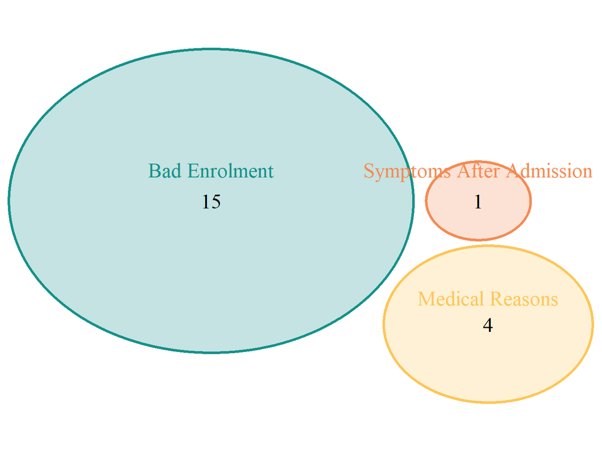

| . |
| --- |

### Humanitas

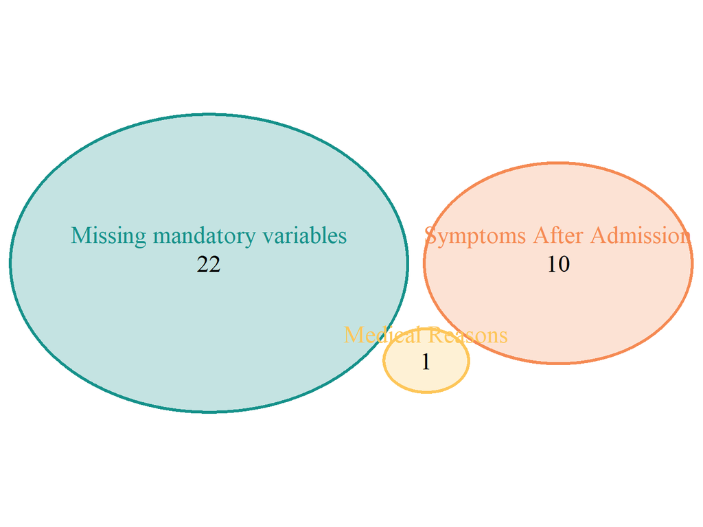

| . |
| --- |

### Monza

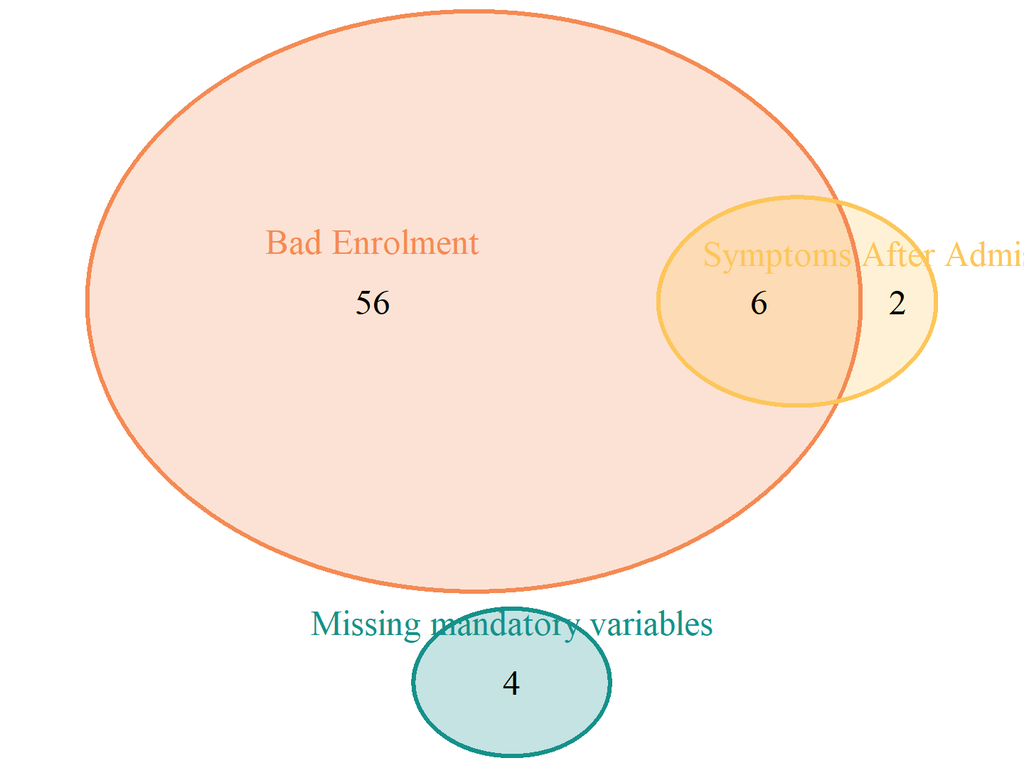

| . |
| --- |

### Spain

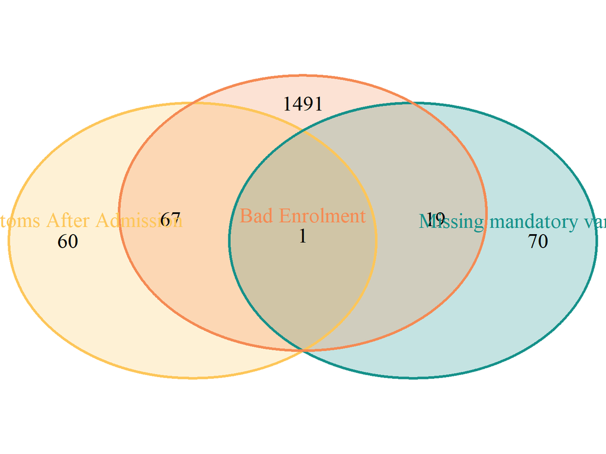

| . |
| --- |

### Italian

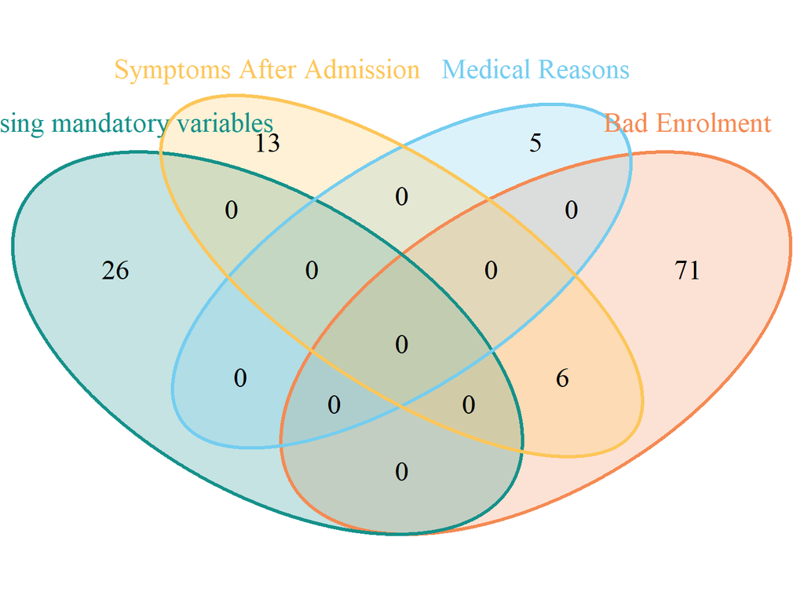

| . |
| --- |

### European

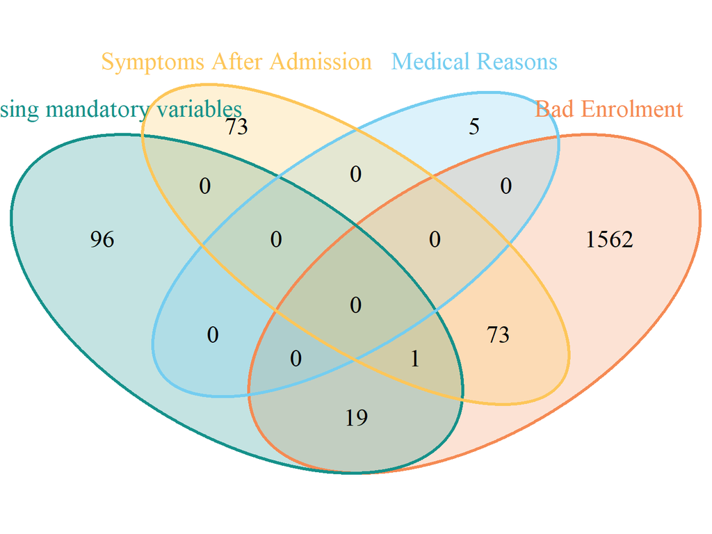

| . |
| --- |

## Age Filtering

All patients younger than 30 year old are deleted because doctor agreement.

### Calabria

| Patients | Reason |
| --- | --- |
| 481-0110 | Patient younger than 30 years old (medical decision). |
| 481-0142 | Patient younger than 30 years old (medical decision). |
| 481-0144 | Patient younger than 30 years old (medical decision). |
| 481-0152 | Patient younger than 30 years old (medical decision). |

### Humanitas

| Patients | Reason |
| --- | --- |
| ICH-133 | Patient younger than 30 years old (medical decision). |
| ICH-320 | Patient younger than 30 years old (medical decision). |
| ICH-374 | Patient younger than 30 years old (medical decision). |
| ICH-408 | Patient younger than 30 years old (medical decision). |
| ICH-459 | Patient younger than 30 years old (medical decision). |
| ICH-518 | Patient younger than 30 years old (medical decision). |

### Monza

| Info |
| --- |
| No observations with problems have been found |

### Spain

| Patients | Reason |
| --- | --- |
| 1225-5 | Patient younger than 30 years old (medical decision). |
| 1226-13 | Patient younger than 30 years old (medical decision). |
| 1232-41 | Patient younger than 30 years old (medical decision). |
| 1233-70 | Patient younger than 30 years old (medical decision). |
| 1233-88 | Patient younger than 30 years old (medical decision). |
| 1234-52 | Patient younger than 30 years old (medical decision). |
| 1234-9 | Patient younger than 30 years old (medical decision). |
| 1237-115 | Patient younger than 30 years old (medical decision). |
| 1239-174 | Patient younger than 30 years old (medical decision). |
| 1243-15 | Patient younger than 30 years old (medical decision). |
| 1243-24 | Patient younger than 30 years old (medical decision). |
| 766-174 | Patient younger than 30 years old (medical decision). |
| 766-64 | Patient younger than 30 years old (medical decision). |
| 771-45 | Patient younger than 30 years old (medical decision). |
| 772-115 | Patient younger than 30 years old (medical decision). |
| 772-143 | Patient younger than 30 years old (medical decision). |
| 773-128 | Patient younger than 30 years old (medical decision). |
| 773-13 | Patient younger than 30 years old (medical decision). |
| 773-71 | Patient younger than 30 years old (medical decision). |
| 773-73 | Patient younger than 30 years old (medical decision). |
| 779-59 | Patient younger than 30 years old (medical decision). |
| 780-102 | Patient younger than 30 years old (medical decision). |
| 780-164 | Patient younger than 30 years old (medical decision). |
| 780-187 | Patient younger than 30 years old (medical decision). |
| 782-116 | Patient younger than 30 years old (medical decision). |
| 782-12 | Patient younger than 30 years old (medical decision). |
| 797-49 | Patient younger than 30 years old (medical decision). |
| 798-100 | Patient younger than 30 years old (medical decision). |
| 798-64 | Patient younger than 30 years old (medical decision). |
| 799-55 | Patient younger than 30 years old (medical decision). |

[output cut: 121 more lines]

### Italian

| Patients | Reason |
| --- | --- |
| 481-0110 | Patient younger than 30 years old (medical decision). |
| 481-0142 | Patient younger than 30 years old (medical decision). |
| 481-0144 | Patient younger than 30 years old (medical decision). |
| 481-0152 | Patient younger than 30 years old (medical decision). |
| ICH-133 | Patient younger than 30 years old (medical decision). |
| ICH-320 | Patient younger than 30 years old (medical decision). |
| ICH-374 | Patient younger than 30 years old (medical decision). |
| ICH-408 | Patient younger than 30 years old (medical decision). |
| ICH-459 | Patient younger than 30 years old (medical decision). |
| ICH-518 | Patient younger than 30 years old (medical decision). |

### European

| Patients | Reason |
| --- | --- |
| 481-0110 | Patient younger than 30 years old (medical decision). |
| 481-0142 | Patient younger than 30 years old (medical decision). |
| 481-0144 | Patient younger than 30 years old (medical decision). |
| 481-0152 | Patient younger than 30 years old (medical decision). |
| ICH-133 | Patient younger than 30 years old (medical decision). |
| ICH-320 | Patient younger than 30 years old (medical decision). |
| ICH-374 | Patient younger than 30 years old (medical decision). |
| ICH-408 | Patient younger than 30 years old (medical decision). |
| ICH-459 | Patient younger than 30 years old (medical decision). |
| ICH-518 | Patient younger than 30 years old (medical decision). |
| 1225-5 | Patient younger than 30 years old (medical decision). |
| 1226-13 | Patient younger than 30 years old (medical decision). |
| 1232-41 | Patient younger than 30 years old (medical decision). |
| 1233-70 | Patient younger than 30 years old (medical decision). |
| 1233-88 | Patient younger than 30 years old (medical decision). |
| 1234-52 | Patient younger than 30 years old (medical decision). |
| 1234-9 | Patient younger than 30 years old (medical decision). |
| 1237-115 | Patient younger than 30 years old (medical decision). |
| 1239-174 | Patient younger than 30 years old (medical decision). |
| 1243-15 | Patient younger than 30 years old (medical decision). |
| 1243-24 | Patient younger than 30 years old (medical decision). |
| 766-174 | Patient younger than 30 years old (medical decision). |
| 766-64 | Patient younger than 30 years old (medical decision). |
| 771-45 | Patient younger than 30 years old (medical decision). |
| 772-115 | Patient younger than 30 years old (medical decision). |
| 772-143 | Patient younger than 30 years old (medical decision). |
| 773-128 | Patient younger than 30 years old (medical decision). |
| 773-13 | Patient younger than 30 years old (medical decision). |
| 773-71 | Patient younger than 30 years old (medical decision). |
| 773-73 | Patient younger than 30 years old (medical decision). |

[output cut: 131 more lines]

## Update: Age Outliers

### Calabria

|  | Original Data | Deleted Wrong Patients | Deleted Age Outlier Patients |
| --- | --- | --- | --- |
| Number of observations | 193 | 173 | 169 |
| Number of variables | 381 | 381 | 381 |

### Humanitas

|  | Original Data | Deleted Wrong Patients | Deleted Age Outlier Patients |
| --- | --- | --- | --- |
| Number of observations | 627 | 594 | 588 |
| Number of variables | 250 | 250 | 250 |

### Monza

|  | Original Data | Deleted Wrong Patients | Deleted Age Outlier Patients |
| --- | --- | --- | --- |
| Number of observations | 642 | 574 | 574 |
| Number of variables | 149 | 149 | 149 |

### Spain

|  | Original Data | Deleted Wrong Patients | Deleted Age Outlier Patients |
| --- | --- | --- | --- |
| Number of observations | 12464 | 10756 | 10605 |
| Number of variables | 88 | 88 | 88 |

### Italian

|  | Original Data | Deleted Wrong Patients | Deleted Age Outlier Patients |
| --- | --- | --- | --- |
| Number of observations | 1462 | 1341 | 1331 |
| Number of variables | 138 | 138 | 138 |

### European

|  | Original Data | Deleted Wrong Patients | Deleted Age Outlier Patients |
| --- | --- | --- | --- |
| Number of observations | 13926 | 12097 | 11936 |
| Number of variables | 59 | 59 | 59 |

## Global Survival Filtering

Patients with negative survival times, greater than 45 days or with missing values will be deleted.

### Calabria

| Patients | Duration for: GlobalSurvival |
| --- | --- |
| 481-0045 | 53 |
| 481-0071 | 54 |
| 481-0100 | 106 |
| 481-0132 | 62 |
| 481-0133 | 51 |
| 481-0137 | 60 |
| 481-0138 | 48 |
| 481-0143 | 73 |
| 481-0146 | 83 |
| 481-0154 | 52 |
| 481-0162 | 66 |
| 481-0167 | 93 |
| 481-0169 | 91 |
| 481-0170 | 50 |
| 481-0172 | 74 |
| 481-0178 | 54 |
| 481-0182 | 108 |
| 481-0183 | 60 |
| 481-0186 | 52 |
| 481-0188 | 59 |
| 481-0192 | 47 |
| 481-0195 | 48 |
| 481-0198 | 70 |
| 481-0199 | 71 |
| 481-0200 | 58 |

### Humanitas

| Patients | Duration for: GlobalSurvival |
| --- | --- |
| ICH-110 | -32 |
| ICH-128 | -26 |
| ICH-134 | -13 |
| ICH-135 | -20 |
| ICH-156 | -45 |
| ICH-178 | -5 |
| ICH-199 | -40 |
| ICH-222 | -9 |
| ICH-234 | -44 |
| ICH-252 | -2 |
| ICH-349 | -5 |
| ICH-350 | -28 |
| ICH-360 | -11 |
| ICH-371 | -13 |
| ICH-372 | -3 |
| ICH-377 | -28 |
| ICH-412 | -24 |
| ICH-586 | -1 |
| ICH-658 | -19 |
| ICH-123 | 55 |
| ICH-124 | 56 |
| ICH-130 | 69 |
| ICH-132 | 67 |
| ICH-149 | 80 |
| ICH-158 | 74 |
| ICH-176 | 50 |
| ICH-18 | 70 |
| ICH-189 | 55 |
| ICH-195 | 53 |
| ICH-201 | 46 |

[output cut: 53 more lines]

### Monza

| Patients | Duration for: GlobalSurvival |
| --- | --- |
| OMNI001-10 | 62 |
| OMNI001-1012 | 77 |
| OMNI001-1017 | 103 |
| OMNI001-1024 | 55 |
| OMNI001-1030 | 69 |
| OMNI001-1034 | 48 |
| OMNI001-1037 | 95 |
| OMNI001-116 | 61 |
| OMNI001-12 | 50 |
| OMNI001-146 | 55 |
| OMNI001-159 | 70 |
| OMNI001-167 | 412 |
| OMNI001-185 | 67 |
| OMNI001-237 | 72 |
| OMNI001-238 | 62 |
| OMNI001-240 | 55 |
| OMNI001-245 | 51 |
| OMNI001-251 | 55 |
| OMNI001-263 | 389 |
| OMNI001-290 | 60 |
| OMNI001-296 | 49 |
| OMNI001-3 | 47 |
| OMNI001-305 | 65 |
| OMNI001-306 | 48 |
| OMNI001-309 | 75 |
| OMNI001-317 | 49 |
| OMNI001-344 | 48 |
| OMNI001-355 | 46 |
| OMNI001-356 | 107 |
| OMNI001-361 | 52 |
| OMNI001-365 | 72 |
| OMNI001-366 | 53 |
| OMNI001-367 | 55 |
| OMNI001-370 | 51 |
| OMNI001-394 | 99 |
| OMNI001-403 | 72 |
| OMNI001-410 | 61 |
| OMNI001-427 | 52 |
| OMNI001-428 | 55 |
| OMNI001-430 | 52 |
| OMNI001-437 | 49 |
| OMNI001-438 | 65 |
| OMNI001-440 | 66 |
| OMNI001-447 | 49 |
| OMNI001-522 | 51 |
| OMNI001-527 | 62 |
| OMNI001-530 | 85 |
| OMNI001-546 | 49 |
| OMNI001-55 | 46 |
| OMNI001-61 | 48 |
| OMNI001-648 | 58 |
| OMNI001-659 | 49 |
| OMNI001-662 | 52 |
| OMNI001-671 | 51 |
| OMNI001-676 | 48 |
| OMNI001-683 | 61 |
| OMNI001-684 | 55 |
| OMNI001-690 | 69 |
| OMNI001-691 | 60 |
| OMNI001-7 | 50 |
| OMNI001-728 | 79 |
| OMNI001-744 | 54 |
| OMNI001-746 | 46 |
| OMNI001-750 | 50 |
| OMNI001-753 | 82 |
| OMNI001-757 | 51 |
| OMNI001-771 | 69 |
| OMNI001-778 | 63 |
| OMNI001-779 | 47 |
| OMNI001-780 | 68 |
| OMNI001-88 | 47 |
| OMNI001-9 | 59 |

### Spain

| Patients | Duration for: GlobalSurvival |
| --- | --- |
| 1233-64 | -9 |
| 1240-117 | -11 |
| 799-7 | -19 |
| 799-76 | -10 |
| 815-85 | -10 |
| 819-38 | -13 |
| 822-73 | -4 |
| 831-58 | -9 |
| 834-59 | -12 |
| 850-65 | -14 |
| 855-14 | -2 |
| 865-75 | -11 |
| 872-108 | -14 |
| 874-31 | -6 |
| 893-34 | -42 |
| 911-14 | -41 |
| 926-12 | -37 |
| 931-30 | -1 |
| 1223-26 | 53 |
| 1223-28 | 47 |
| 1223-4 | 54 |
| 1223-94 | 71 |
| 1223-95 | 63 |
| 1226-8 | 46 |
| 1227-1 | 69 |
| 1230-2 | 73 |
| 1232-12 | 79 |
| 1232-8 | 47 |
| 1233-54 | 79 |
| 1233-67 | 46 |

[output cut: 385 more lines]

### Italian

| Patients | Duration for: GlobalSurvival |
| --- | --- |
| ICH-110 | -32 |
| ICH-128 | -26 |
| ICH-134 | -13 |
| ICH-135 | -20 |
| ICH-156 | -45 |
| ICH-178 | -5 |
| ICH-199 | -40 |
| ICH-222 | -9 |
| ICH-234 | -44 |
| ICH-252 | -2 |
| ICH-349 | -5 |
| ICH-350 | -28 |
| ICH-360 | -11 |
| ICH-371 | -13 |
| ICH-372 | -3 |
| ICH-377 | -28 |
| ICH-412 | -24 |
| ICH-586 | -1 |
| ICH-658 | -19 |
| 481-0045 | 53 |
| 481-0071 | 54 |
| 481-0100 | 106 |
| 481-0132 | 62 |
| 481-0133 | 51 |
| 481-0137 | 60 |
| 481-0138 | 48 |
| 481-0143 | 73 |
| 481-0146 | 83 |
| 481-0154 | 52 |
| 481-0162 | 66 |

[output cut: 150 more lines]

### European

| Patients | Duration for: GlobalSurvival |
| --- | --- |
| ICH-110 | -32 |
| ICH-128 | -26 |
| ICH-134 | -13 |
| ICH-135 | -20 |
| ICH-156 | -45 |
| ICH-178 | -5 |
| ICH-199 | -40 |
| ICH-222 | -9 |
| ICH-234 | -44 |
| ICH-252 | -2 |
| ICH-349 | -5 |
| ICH-350 | -28 |
| ICH-360 | -11 |
| ICH-371 | -13 |
| ICH-372 | -3 |
| ICH-377 | -28 |
| ICH-412 | -24 |
| ICH-586 | -1 |
| ICH-658 | -19 |
| 1233-64 | -9 |
| 1240-117 | -11 |
| 799-7 | -19 |
| 799-76 | -10 |
| 815-85 | -10 |
| 819-38 | -13 |
| 822-73 | -4 |
| 831-58 | -9 |
| 834-59 | -12 |
| 850-65 | -14 |
| 855-14 | -2 |

[output cut: 565 more lines]

## Update: Survival Time

### Calabria

|  | Original Data | Deleted Wrong Patients | Deleted Age Outlier Patients | GlobalSurvival Filter |
| --- | --- | --- | --- | --- |
| Number of observations | 193 | 173 | 169 | 144 |
| Number of variables | 381 | 381 | 381 | 382 |

### Humanitas

|  | Original Data | Deleted Wrong Patients | Deleted Age Outlier Patients | GlobalSurvival Filter |
| --- | --- | --- | --- | --- |
| Number of observations | 627 | 594 | 588 | 505 |
| Number of variables | 250 | 250 | 250 | 251 |

### Monza

|  | Original Data | Deleted Wrong Patients | Deleted Age Outlier Patients | GlobalSurvival Filter |
| --- | --- | --- | --- | --- |
| Number of observations | 642 | 574 | 574 | 502 |
| Number of variables | 149 | 149 | 149 | 150 |

### Spain

|  | Original Data | Deleted Wrong Patients | Deleted Age Outlier Patients | GlobalSurvival Filter |
| --- | --- | --- | --- | --- |
| Number of observations | 12464 | 10756 | 10605 | 10190 |
| Number of variables | 88 | 88 | 88 | 89 |

### Italian

|  | Original Data | Deleted Wrong Patients | Deleted Age Outlier Patients | GlobalSurvival Filter |
| --- | --- | --- | --- | --- |
| Number of observations | 1462 | 1341 | 1331 | 1151 |
| Number of variables | 138 | 138 | 138 | 139 |

### European

|  | Original Data | Deleted Wrong Patients | Deleted Age Outlier Patients | GlobalSurvival Filter |
| --- | --- | --- | --- | --- |
| Number of observations | 13926 | 12097 | 11936 | 11341 |
| Number of variables | 59 | 59 | 59 | 60 |

## Generate Survival Dataframe

This matrix/data.frame get the “rownames” as the patients ID and has two columns. The global survival and the event variable as TRUE for those patients that reach the event and FALSE for those are censored.

## Generate Qualitative Age Variable from better division of survival

Age is spitted in a maximum of 10 categories. For each category a minimum number of patients is needed. In case the next category not reach the minimum, all the patients will be to the same category and the split will be stopped.

### Calabria

#### age_estimateyears

|  | cutpoint | statistic | observations over cutpoint |
| --- | --- | --- | --- |
| cutpoint_1 | 83 | 6.070217 | 24 |
| cutpoint_2 | 63 | 2.478470 | 73 |
| cutpoint_3 | 30 | NaN | 47 |

### Humanitas

#### age_estimateyears

|  | cutpoint | statistic | observations over cutpoint |
| --- | --- | --- | --- |
| cutpoint_1 | 71 | 7.483776 | 187 |
| cutpoint_2 | 62 | 2.980848 | 119 |
| cutpoint_3 | 57 | 1.406288 | 57 |
| cutpoint_4 | 49 | 2.038944 | 66 |
| cutpoint_5 | 48 | 1.966155 | 11 |
| cutpoint_6 | 30 | NaN | 65 |

### Monza

#### age_estimateyears

|  | cutpoint | statistic | observations over cutpoint |
| --- | --- | --- | --- |
| cutpoint_1 | 70 | 8.575097 | 158 |
| cutpoint_2 | 59 | 3.814708 | 146 |
| cutpoint_3 | 30 | NaN | 198 |

### Spain

#### age_estimateyears

|  | cutpoint | statistic | observations over cutpoint |
| --- | --- | --- | --- |
| cutpoint_1 | 76.0 | 29.586673 | 2882 |
| cutpoint_2 | 68.8 | 15.176837 | 2063 |
| cutpoint_3 | 62.0 | 6.382898 | 1357 |
| cutpoint_4 | 54.0 | 3.979260 | 1582 |
| cutpoint_5 | 30.0 | NaN | 2306 |

### Italian

#### age_estimateyears

|  | cutpoint | statistic | observations over cutpoint |
| --- | --- | --- | --- |
| cutpoint_1 | 70 | 11.488072 | 437 |
| cutpoint_2 | 65 | 4.752659 | 154 |
| cutpoint_3 | 57 | 2.805811 | 221 |
| cutpoint_4 | 30 | NaN | 339 |

### European

#### age_estimateyears

|  | cutpoint | statistic | observations over cutpoint |
| --- | --- | --- | --- |
| cutpoint_1 | 71 | 31.257534 | 4587 |
| cutpoint_2 | 62 | 10.221220 | 2380 |
| cutpoint_3 | 54 | 4.199028 | 1800 |
| cutpoint_4 | 52 | 1.580763 | 394 |
| cutpoint_5 | 30 | NaN | 2180 |

## Change specific levels in qualitative variables

Variable cough_ceoccur_v2_2 has been change in merge databases because Calabria hospital have more categories than the other ones. So, we collapse those categories into the others.

## Change missing values in Var ‘oxygen_cmdose’

If any oxygen therapy has been applied (var: oxygen_cmoccur). Variable “oxygen_cmdose” indicates “Maximum O2 flow volume”. When no oxygen therapy is given, the value is a missing value. We changed the missing value for a new category with the value “0L/min”.

## Change level order

In out case, we want to compare having a specific feature against to not have it. We are going to change all the level order to next order: NO-YES / Unchecked-Checked / Male-Female…

## Summary Information

### Calabria

|  | Original Data | Deleted Wrong Patients | Deleted Age Outlier Patients | GlobalSurvival Filter | Variable filter |
| --- | --- | --- | --- | --- | --- |
| Number of observations | 193 | 173 | 169 | 144 | 144 |
| Number of variables | 381 | 381 | 381 | 382 | 382 |

### Humanitas

|  | Original Data | Deleted Wrong Patients | Deleted Age Outlier Patients | GlobalSurvival Filter | Variable filter |
| --- | --- | --- | --- | --- | --- |
| Number of observations | 627 | 594 | 588 | 505 | 505 |
| Number of variables | 250 | 250 | 250 | 251 | 251 |

### Monza

|  | Original Data | Deleted Wrong Patients | Deleted Age Outlier Patients | GlobalSurvival Filter | Variable filter |
| --- | --- | --- | --- | --- | --- |
| Number of observations | 642 | 574 | 574 | 502 | 502 |
| Number of variables | 149 | 149 | 149 | 150 | 150 |

### Spain

|  | Original Data | Deleted Wrong Patients | Deleted Age Outlier Patients | GlobalSurvival Filter | Variable filter |
| --- | --- | --- | --- | --- | --- |
| Number of observations | 12464 | 10756 | 10605 | 10190 | 10190 |
| Number of variables | 88 | 88 | 88 | 89 | 89 |

### Italian

|  | Original Data | Deleted Wrong Patients | Deleted Age Outlier Patients | GlobalSurvival Filter | Variable filter |
| --- | --- | --- | --- | --- | --- |
| Number of observations | 1462 | 1341 | 1331 | 1151 | 1151 |
| Number of variables | 138 | 138 | 138 | 139 | 139 |

### European

|  | Original Data | Deleted Wrong Patients | Deleted Age Outlier Patients | GlobalSurvival Filter | Variable filter |
| --- | --- | --- | --- | --- | --- |
| Number of observations | 13926 | 12097 | 11936 | 11341 | 11341 |
| Number of variables | 59 | 59 | 59 | 60 | 60 |

## Save Process

Databases are saved in .RData and .xlsx format with their new colnames. Excel format does not save the same R class for each variable. We recommend to work with .RData files in case you want to do your own study.